# Multivariate_1

DW

2024-03-13

#Question 1:(Textbook1.19) Get data and Draw 2 graphs

```r
data <- read.csv("C:\\Users\\Synlim\\Desktop\\T4-6.csv")
colnames(data) <- c('Independence','Support','Benevolence','Conformity','Leadership','Gender','Socio')

mydata <- data[,c('Independence','Support','Benevolence','Conformity','Leadership')]
head(mydata)
```

|  | Independence | Support | Benevolence | Conformity | Leadership |
| --- | --- | --- | --- | --- | --- |
| 1 | 12 | 13 | 24 | 25 | 6 |
| 2 | 14 | 20 | 15 | 16 | 7 |
| 3 | 18 | 20 | 17 | 12 | 6 |
| 4 | 9 | 22 | 22 | 21 | 6 |
| 5 | 18 | 15 | 17 | 25 | 9 |
| 6 | 12 | 18 | 29 | 18 | 4 |

```r
plot(1,1,type = 'n', xlim = c(0,nrow(mydata)), ylim = c(0,max(mydata)),xlab = 'X', ylab = 'Y', main = 'Scatter plot of data')
nrow(mydata)
```

```
## [1] 129
```

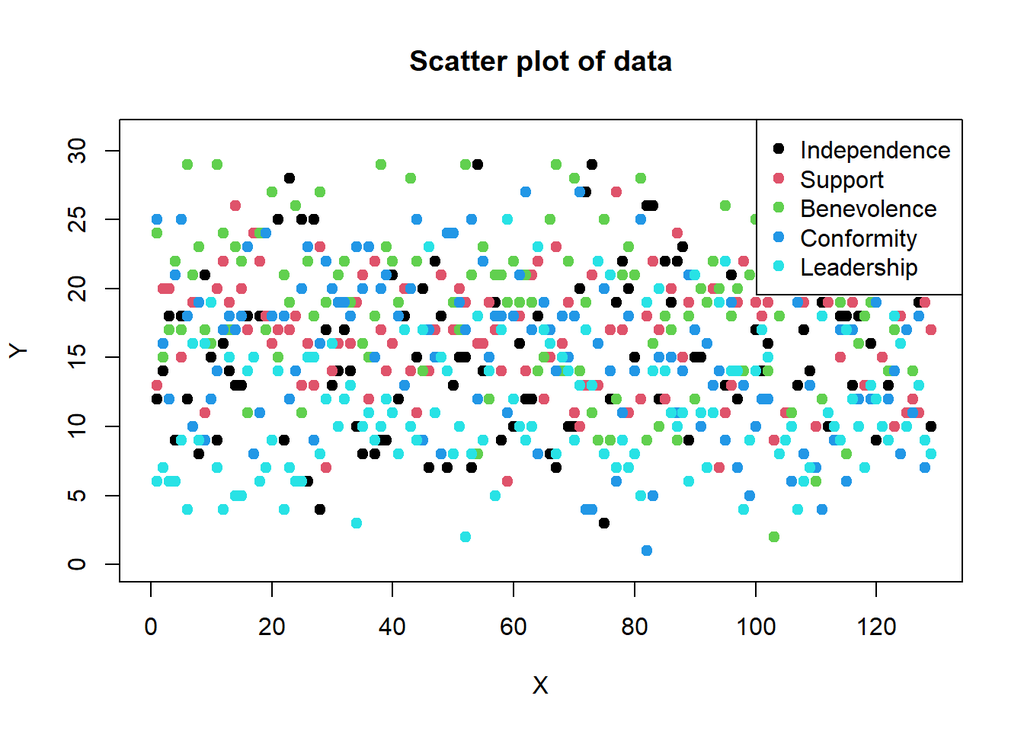

```r
for (i in 1:5){
  points(c(1:nrow(mydata)),mydata[,i], col = i, pch=19)
}
legend("topright", legend=colnames(mydata), col=1:5, pch=19)
```

```r
#添加图例
```

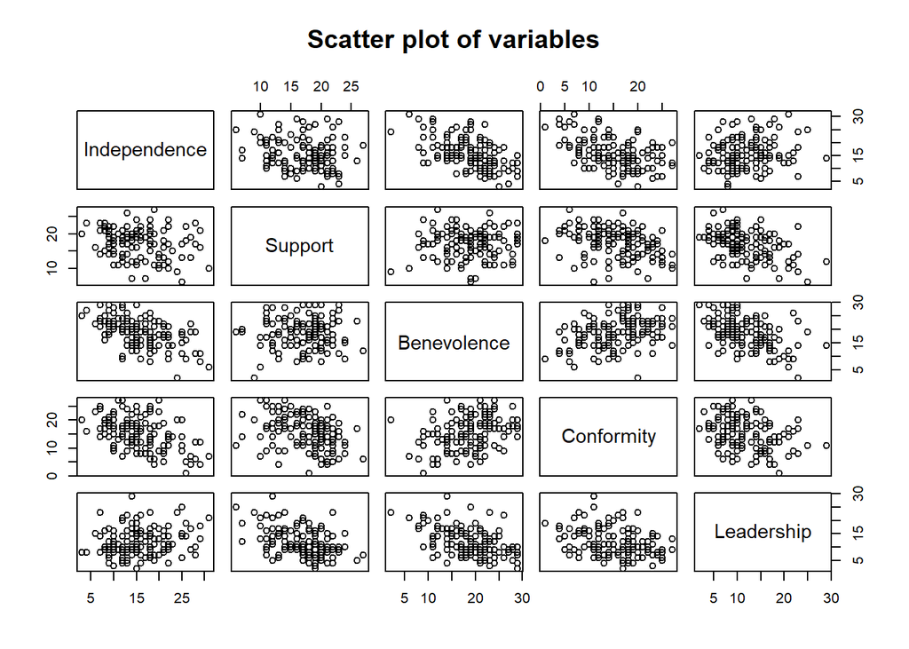

```r
pairs(~Independence + Support + Benevolence + Conformity + Leadership, data=mydata, main="Scatter plot of variables")
```

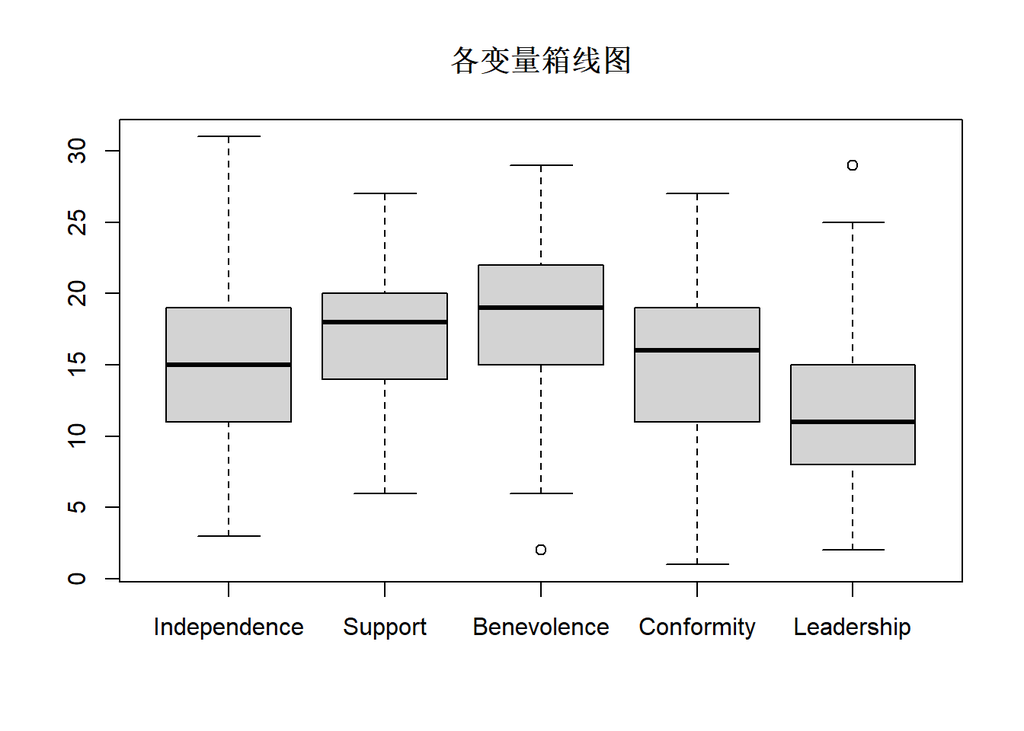

```r
boxplot(mydata$Independence, mydata$Support, mydata$Benevolence, mydata$Conformity, mydata$Leadership,
        names=c("Independence", "Support", "Benevolence", "Conformity", "Leadership"),
        main="各变量箱线图")
```

#Question 2:(Textbook1.26a) Compute x_bar,Sn and R arrays.

$$\bar{x_k} = \frac{1}{n} \sum_{i=1}^n
x_{ik}$$
According to the equation above,

```r
x_bar = colMeans(mydata)
print(x_bar)
```

```
## Independence      Support  Benevolence   Conformity   Leadership
##     15.58140     17.10853     18.82171     15.46512     11.73643
```

```r
class(x_bar)
```

```
## [1] "numeric"
```

Now we calculate the variance-covariance matrix Sn
$$s_{ik} = \frac{1}{n} \sum_{j=1}^n (x_{ji} -
\bar{x_i})(x_{jk} - \bar{x_k})$$

```r
Sn = matrix(0, nrow = ncol(mydata), ncol = ncol(mydata))
mydata <- as.matrix(mydata)
bar_1 <-  c(15.58140,17.10853,18.82171,15.46512,11.73643)

for (i in 1:ncol(mydata)){
  bar_xi = bar_1[i]
  for (k in 1:ncol(mydata)){
    bar_xk = bar_1[k]
    sum1 = 0
    for (j in 1:nrow(mydata)){
    sum1 <- sum1 + (mydata[j,i] - bar_xi)*(mydata[j,k] - bar_xk)
    }
    sum1 <- sum1/nrow(mydata)
    Sn[i,k] <- sum1
  }

}
print(Sn)
```

```
##            [,1]       [,2]        [,3]       [,4]       [,5]
## [1,]  33.747251 -3.9158103 -17.6482783 -16.371192   5.781143
## [2,]  -3.915810 17.3835707   0.2674118  -7.724896  -8.746590
## [3,] -17.648278  0.2674118  29.6658855   9.517036 -13.969473
## [4,] -16.371192 -7.7248963   9.5170362  32.884442  -9.916171
## [5,]   5.781143 -8.7465897 -13.9694730  -9.916171  26.953789
```

```r
print(nrow(mydata))
```

```
## [1] 129
```

```r
print(ncol(mydata))
```

```
## [1] 5
```

Now we need to calculate sample correlation matrix R
$$S = \frac{n}{n-1} S_n$$
$$R = D^{(-\frac{1}{2})} S
D^{(-\frac{1}{2})}$$

```r
diag_ele <- diag(Sn)
diag_ele <- sqrt(diag_ele)
D_inv <- diag(1/diag_ele)
S <- (nrow(mydata)/(nrow(mydata)-1)) * Sn
R <- D_inv %*% S %*% D_inv
print(R)
```

```
##            [,1]        [,2]        [,3]       [,4]       [,5]
## [1,]  1.0078125 -0.16293437 -0.56212672 -0.4952741  0.1931810
## [2,] -0.1629344  1.00781250  0.01186758 -0.3256174 -0.4072294
## [3,] -0.5621267  0.01186758  1.00781250  0.3070843 -0.4978760
## [4,] -0.4952741 -0.32561745  0.30708427  1.0078125 -0.3356747
## [5,]  0.1931810 -0.40722937 -0.49787600 -0.3356747  1.0078125
```

Most of the correlations are under 0.5, so the correlations are not that strong!

#Question 3:(Textbook2.7)

```r
A <- Sn
eigen_result <- eigen(A)
eigenvalues <- eigen_result$values
eigenvectors <- eigen_result$vectors

print("Eigenvalues of A:")
```

```
## [1] "Eigenvalues of A:"
```

```r
print(eigenvalues)
```

```
## [1] 68.405579 31.341601 22.170613 16.350209  2.366935
```

```r
print("Eigenvectors of A:")
```

```
## [1] "Eigenvectors of A:"
```

```r
print(eigenvectors)
```

```
##             [,1]       [,2]       [,3]        [,4]      [,5]
## [1,]  0.57132950  0.1056986 -0.6398502  0.31558562 0.3916732
## [2,] -0.03626386  0.6056973  0.1671809 -0.51760834 0.5796101
## [3,] -0.52225243  0.2183399  0.1453373  0.73175050 0.3507112
## [4,] -0.50242226 -0.5491354 -0.4411288 -0.29976281 0.4019575
## [5,]  0.38352550 -0.5222420  0.5890032  0.08468048 0.4754745
```

Now we get the eigen-decomposition of A
$$A = Q \lambda Q^{-1}$$

```r
Q <- eigenvectors
lamb <- diag(eigenvalues)
Q_inv <- solve(Q)
print(Q)
```

```
##             [,1]       [,2]       [,3]        [,4]      [,5]
## [1,]  0.57132950  0.1056986 -0.6398502  0.31558562 0.3916732
## [2,] -0.03626386  0.6056973  0.1671809 -0.51760834 0.5796101
## [3,] -0.52225243  0.2183399  0.1453373  0.73175050 0.3507112
## [4,] -0.50242226 -0.5491354 -0.4411288 -0.29976281 0.4019575
## [5,]  0.38352550 -0.5222420  0.5890032  0.08468048 0.4754745
```

```r
print(lamb)
```

```
##          [,1]    [,2]     [,3]     [,4]     [,5]
## [1,] 68.40558  0.0000  0.00000  0.00000 0.000000
## [2,]  0.00000 31.3416  0.00000  0.00000 0.000000
## [3,]  0.00000  0.0000 22.17061  0.00000 0.000000
## [4,]  0.00000  0.0000  0.00000 16.35021 0.000000
## [5,]  0.00000  0.0000  0.00000  0.00000 2.366935
```

```r
print(Q_inv)
```

```
##            [,1]        [,2]       [,3]       [,4]        [,5]
## [1,]  0.5713295 -0.03626386 -0.5222524 -0.5024223  0.38352550
## [2,]  0.1056986  0.60569726  0.2183399 -0.5491354 -0.52224195
## [3,] -0.6398502  0.16718095  0.1453373 -0.4411288  0.58900316
## [4,]  0.3155856 -0.51760834  0.7317505 -0.2997628  0.08468048
## [5,]  0.3916732  0.57961012  0.3507112  0.4019575  0.47547453
```

Now we need to get A_inverse and the respective eigenvalues/vectors.

```r
A_inv <- solve(A)
print(A_inv)
```

```
##            [,1]       [,2]       [,3]       [,4]       [,5]
## [1,] 0.09449873 0.08283638 0.06433858 0.06741169 0.06475776
## [2,] 0.08283638 0.17130536 0.06830835 0.09424785 0.10789793
## [3,] 0.06433858 0.06830835 0.09117562 0.04326115 0.07153632
## [4,] 0.06741169 0.09424785 0.04326115 0.09584573 0.07380739
## [5,] 0.06475776 0.10789793 0.07153632 0.07380739 0.12245315
```

```r
eigen_result <- eigen(A_inv)
eigenvalues <- eigen_result$values
eigenvectors <- eigen_result$vectors
cat('\n')
```

```r
print("Eigenvalues of A_inverse:")
```

```
## [1] "Eigenvalues of A_inverse:"
```

```r
print(eigenvalues)
```

```
## [1] 0.42248738 0.06116130 0.04510475 0.03190647 0.01461869
```

```r
print("Eigenvectors of A_inverse:")
```

```
## [1] "Eigenvectors of A_inverse:"
```

```r
print(eigenvectors)
```

```
##            [,1]        [,2]       [,3]       [,4]        [,5]
## [1,] -0.3916732  0.31558562 -0.6398502 -0.1056986  0.57132950
## [2,] -0.5796101 -0.51760834  0.1671809 -0.6056973 -0.03626386
## [3,] -0.3507112  0.73175050  0.1453373 -0.2183399 -0.52225243
## [4,] -0.4019575 -0.29976281 -0.4411288  0.5491354 -0.50242226
## [5,] -0.4754745  0.08468048  0.5890032  0.5222420  0.38352550
```

#Question 4:(Textbook4.39) Find possible outliers first Now we detect outliers
$$z_{jk} = \frac{x_{jk} -
\bar{x_k}}{\sqrt{s_{kk}}}$$

```r
#Make a dot plot for each variable
#Pairwise scatter plot has been shown in the very start
Z = matrix(0, nrow = nrow(mydata), ncol = ncol(mydata))
for (k in 1:ncol(mydata)){
  bar_x <- x_bar[k]
  sq_skk <- sqrt(Sn[k,k])
  for (j in 1:nrow(mydata)){
    Z[j,k] <- (mydata[j,k] - bar_x)/sq_skk
  }
}
head.matrix(Z)
```

```
##            [,1]       [,2]       [,3]        [,4]       [,5]
## [1,] -0.6165000 -0.9854093  0.9507320  1.66272399 -1.1049232
## [2,] -0.2722208  0.6935050 -0.7016630  0.09327476 -0.9123082
## [3,]  0.4163376  0.6935050 -0.3344641 -0.60425823 -1.1049232
## [4,] -1.1329188  1.1731949  0.5835331  0.96519100 -1.1049232
## [5,]  0.4163376 -0.5057195 -0.3344641  1.66272399 -0.5270782
## [6,] -0.6165000  0.2138152  1.8687291  0.44204126 -1.4901532
```

```r
a <- any(abs(Z) > 3.5)
if (a){
  print('There are outliers')
} else {
  print('No outliers')
}
```

```
## [1] "No outliers"
```

```r
S <- cov(mydata)
S_inv <- solve(S)
dj_s <- apply(mydata, 1, function(x) { #‘1’表示按行操作
  (x - x_bar) %*% S_inv %*% (x - x_bar)
})
print(dj_s)
```

```
##   [1]  4.1111645  4.4813190  3.8902764  3.4042313  5.3848079  4.1004111
##   [7]  3.9777251  4.6688247  6.3499293  2.2170833  4.5565695  4.2794583
##  [13]  3.4473608  7.7383309  1.7664651  7.6247442  4.7152027  4.1419245
##  [19]  5.9863811  2.7335928  5.3981623  4.9759575  7.4875098  3.8723421
##  [25] 11.1115516  4.9214113  4.5117896  5.8257333  7.7822770  2.1608792
##  [31]  0.4577308  2.1916899  0.3980934  3.7865547  4.7887640  4.8624787
##  [37]  4.9869157  4.8972048  2.1625959  2.8537078  1.8347901  3.7954594
##  [43]  3.4867012  4.2539648  3.4830405 11.0031777  3.2767171  2.3841173
##  [49]  4.5778080  2.8091957  2.1411709  5.7194294  5.9339552  8.4663617
##  [55]  2.3806219  2.6148224  2.7043567  3.1204802 15.0633025  1.1903425
##  [61]  2.9676350  4.2897572  1.4147253 13.8097664  2.6685229  4.1838543
##  [67]  6.3405175  1.6247675  2.1167606  8.0384772  8.9051114  8.9222871
##  [73]  7.2243672  6.2860198  5.0796131  7.8461755  9.3611841  2.9102192
##  [79]  5.9990286  1.1366896  5.9927243  7.8433171  8.1563929  6.4677113
##  [85]  2.5786082  2.0890368  6.7101059  2.5518835  5.3174237  4.8485376
##  [91]  1.5648658  1.1291531  1.5721754 10.5088490 12.2312230  3.8132964
##  [97]  5.6753241  6.1490301  5.2068020  6.4909609  3.7598761  1.4215289
## [103] 14.8728121  5.1485133  5.0187660  7.7354947  2.2794536  8.3080886
## [109]  2.0538453 11.1110379  5.2848025  4.1347976  5.3772303  1.2219970
## [115]  8.1405445  3.6773157  3.8090842  4.8307575  2.0430196  1.9380712
## [121]  2.2696016  5.9276632  4.0732410  2.7690568  8.4638485 12.0817827
## [127]  4.0474529  9.2703902  1.6580592
```

```r
# 按照d^2的值进行排序
d_squared_sorted <- sort(dj_s)
print(d_squared_sorted)
```

```
##   [1]  0.3980934  0.4577308  1.1291531  1.1366896  1.1903425  1.2219970
##   [7]  1.4147253  1.4215289  1.5648658  1.5721754  1.6247675  1.6580592
##  [13]  1.7664651  1.8347901  1.9380712  2.0430196  2.0538453  2.0890368
##  [19]  2.1167606  2.1411709  2.1608792  2.1625959  2.1916899  2.2170833
##  [25]  2.2696016  2.2794536  2.3806219  2.3841173  2.5518835  2.5786082
##  [31]  2.6148224  2.6685229  2.7043567  2.7335928  2.7690568  2.8091957
##  [37]  2.8537078  2.9102192  2.9676350  3.1204802  3.2767171  3.4042313
##  [43]  3.4473608  3.4830405  3.4867012  3.6773157  3.7598761  3.7865547
##  [49]  3.7954594  3.8090842  3.8132964  3.8723421  3.8902764  3.9777251
##  [55]  4.0474529  4.0732410  4.1004111  4.1111645  4.1347976  4.1419245
##  [61]  4.1838543  4.2539648  4.2794583  4.2897572  4.4813190  4.5117896
##  [67]  4.5565695  4.5778080  4.6688247  4.7152027  4.7887640  4.8307575
##  [73]  4.8485376  4.8624787  4.8972048  4.9214113  4.9759575  4.9869157
##  [79]  5.0187660  5.0796131  5.1485133  5.2068020  5.2848025  5.3174237
##  [85]  5.3772303  5.3848079  5.3981623  5.6753241  5.7194294  5.8257333
##  [91]  5.9276632  5.9339552  5.9863811  5.9927243  5.9990286  6.1490301
##  [97]  6.2860198  6.3405175  6.3499293  6.4677113  6.4909609  6.7101059
## [103]  7.2243672  7.4875098  7.6247442  7.7354947  7.7383309  7.7822770
## [109]  7.8433171  7.8461755  8.0384772  8.1405445  8.1563929  8.3080886
## [115]  8.4638485  8.4663617  8.9051114  8.9222871  9.2703902  9.3611841
## [121] 10.5088490 11.0031777 11.1110379 11.1115516 12.0817827 12.2312230
## [127] 13.8097664 14.8728121 15.0633025
```

```r
# 计算χ²分布的理论分位数
p <- (1:nrow(mydata)) / (nrow(mydata) + 1)
chi_quantiles <- qchisq(p, df=ncol(mydata))
print(chi_quantiles)
```

```
##   [1]  0.4949319  0.6692155  0.8017267  0.9135793  1.0126569  1.1029057
##   [7]  1.1866273  1.2652991  1.3399352  1.4112661  1.4798388  1.5460750
##  [13]  1.6103080  1.6728066  1.7337917  1.7934469  1.8519276  1.9093663
##  [19]  1.9658772  2.0215599  2.0765017  2.1307800  2.1844635  2.2376141
##  [25]  2.2902875  2.3425343  2.3944006  2.4459287  2.4971576  2.5481235
##  [31]  2.5988601  2.6493985  2.6997685  2.7499977  2.8001123  2.8501374
##  [37]  2.9000967  2.9500130  2.9999081  3.0498032  3.0997185  3.1496739
##  [43]  3.1996885  3.2497814  3.2999708  3.3502749  3.4007117  3.4512987
##  [49]  3.5020535  3.5529937  3.6041366  3.6554996  3.7071003  3.7589561
##  [55]  3.8110848  3.8635042  3.9162326  3.9692881  4.0226896  4.0764561
##  [61]  4.1306070  4.1851621  4.2401420  4.2955675  4.3514602  4.4078422
##  [67]  4.4647366  4.5221669  4.5801577  4.6387345  4.6979237  4.7577529
##  [73]  4.8182508  4.8794472  4.9413734  5.0040623  5.0675482  5.1318671
##  [79]  5.1970569  5.2631576  5.3302113  5.3982624  5.4673581  5.5375482
##  [85]  5.6088855  5.6814265  5.7552309  5.8303627  5.9068902  5.9848865
##  [91]  6.0644300  6.1456050  6.2285023  6.3132198  6.3998636  6.4885486
##  [97]  6.5793998  6.6725533  6.7681579  6.8663768  6.9673894  7.0713934
## [103]  7.1786078  7.2892761  7.4036697  7.5220928  7.6448877  7.7724417
## [109]  7.9051956  8.0436534  8.1883960  8.3400969  8.4995439  8.6676664
## [115]  8.8455713  9.0345925  9.2363569  9.4528780  9.6866898  9.9410440
## [121] 10.2202109 10.5299572 10.8783431 11.2771331 11.7444970 12.3107447
## [127] 13.0324115 14.0356382 15.7194848
```

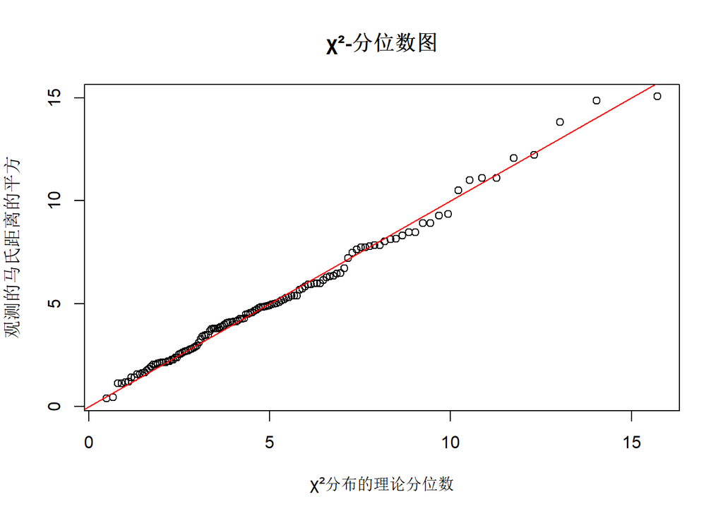

```r
# 绘制χ²-分位数图
plot(chi_quantiles, d_squared_sorted, xlab="χ²分布的理论分位数", ylab="观测的马氏距离的平方", main="χ²-分位数图")
abline(0, 1, col="red")  # 添加y=x参考线
```

```r
# 判断向量中的每个点是否超过卡方(0.0005)
b <- any(dj_s > qchisq(0.9995,ncol(mydata)))
if (b){
  print('There are outliers')
} else {
  print('No outliers')
}
```

```
## [1] "No outliers"
```

Now we have proved that NO outliers exist ## Test the marginal normal dist of mydata using QQ-Plot

W统计量（W）：用于评估样本数据与正态分布之间的拟合程度。W值越接近1，表示数据越符合正态分布。

p值（p-value）：表示在零假设（样本数据来自于正态分布）成立的情况下，观察到当前统计量或更极端统计量的概率。如果p值小于显著性水平（通常为0.05），则拒绝零假设，即认为数据不服从正态分布。

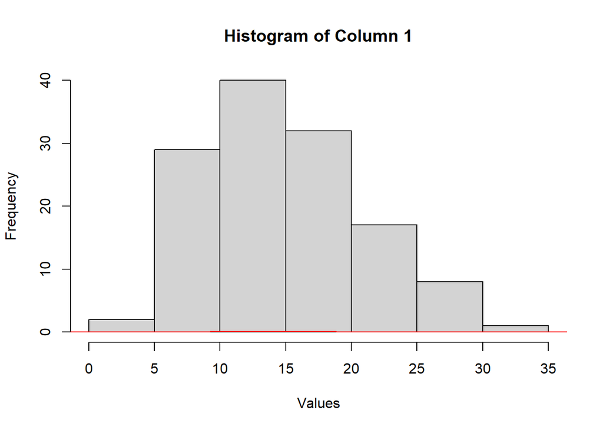

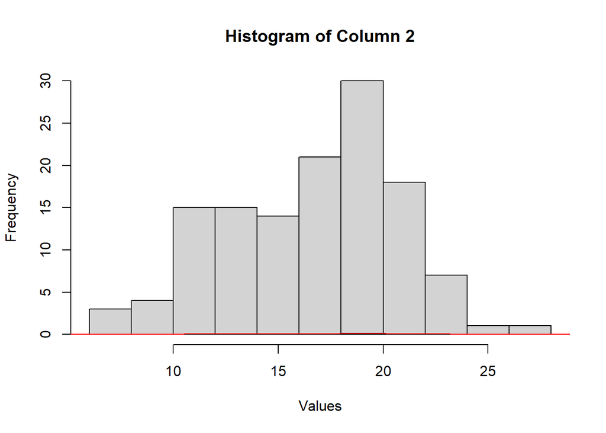

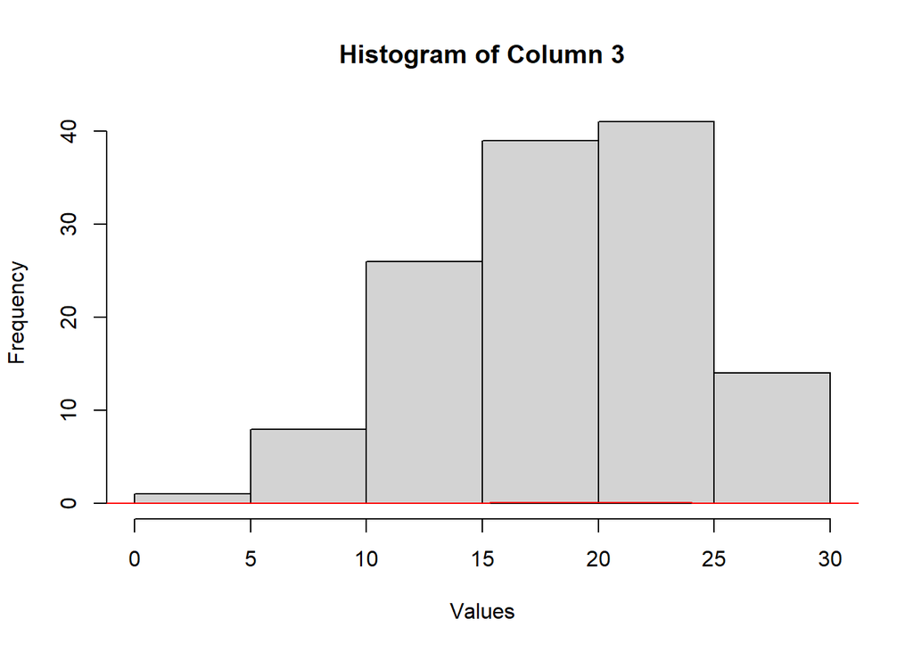

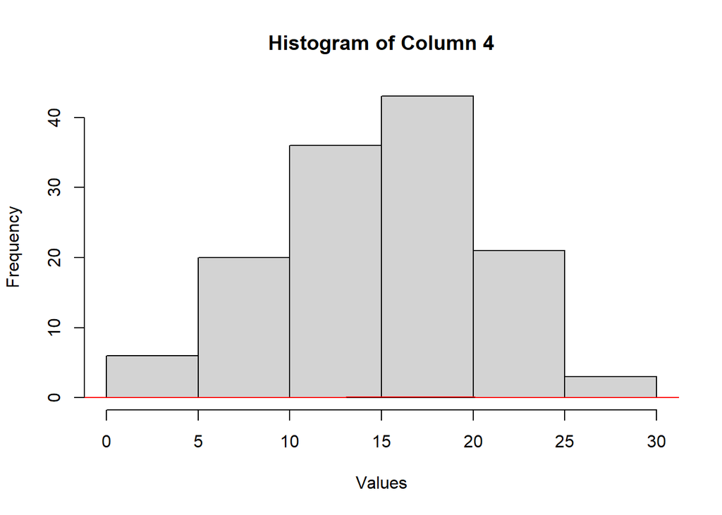

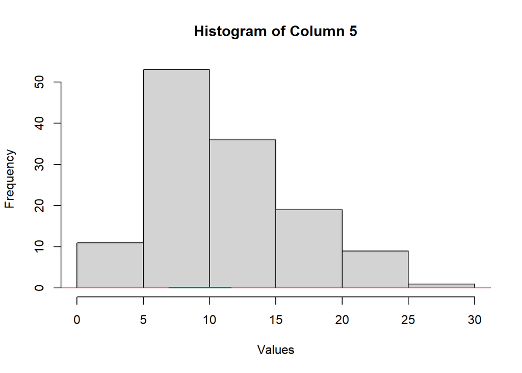

```r
#par(mfrow=c(2,2))
for (i in 1:ncol(mydata)) {
  hist(mydata[,i], main=paste("Histogram of Column", i), xlab="Values")
  lines(density(mydata[,i]), col="red") #密度估计曲线
}
```

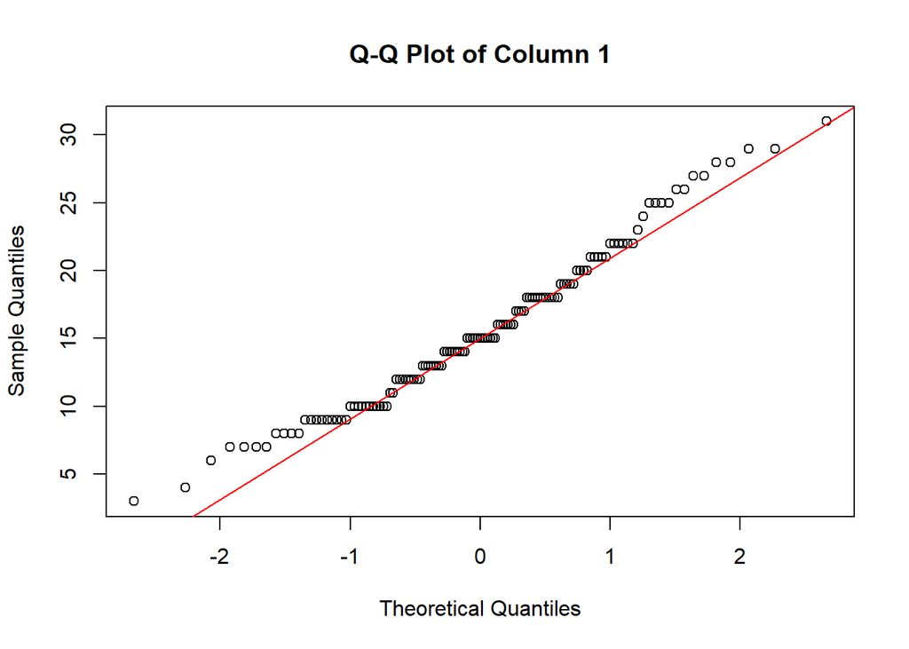

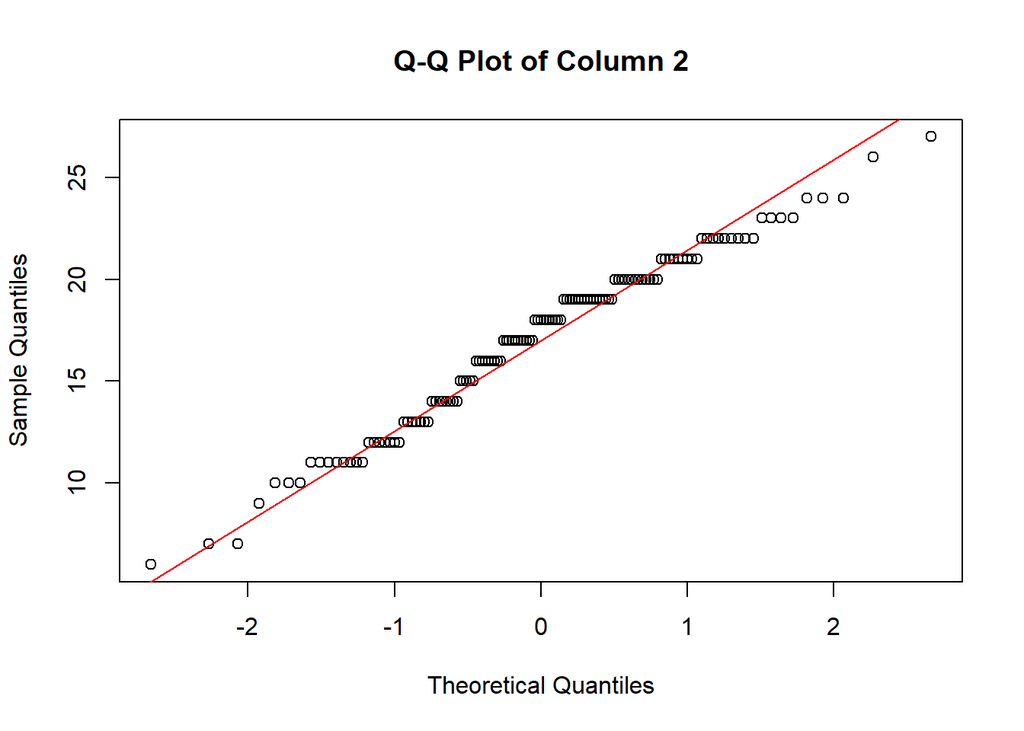

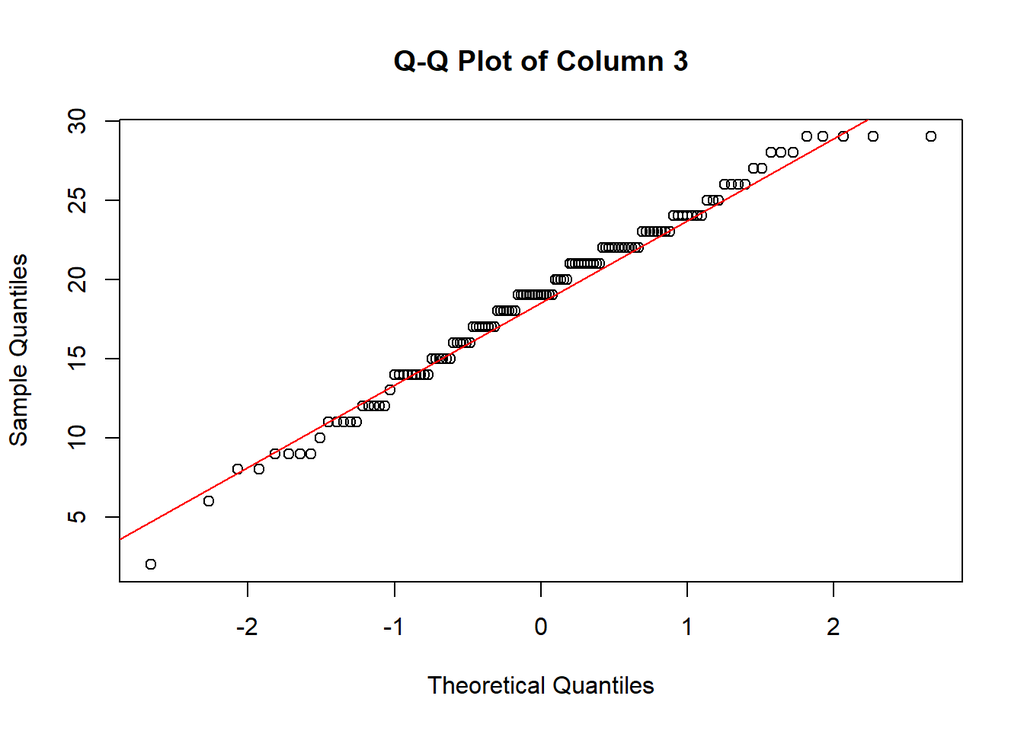

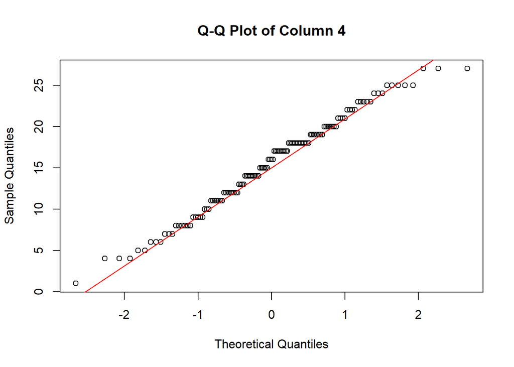

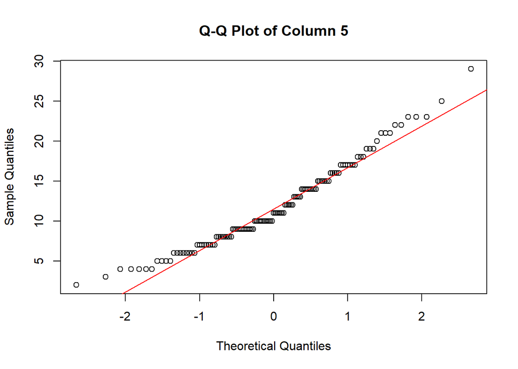

```r
# 绘制 Q-Q 图
#par(mfrow=c(1,1))
for (i in 1:ncol(mydata)) {
  qqnorm(mydata[,i], main=paste("Q-Q Plot of Column", i))
  qqline(mydata[,i], col="red")
}
```

```r
for (i in 1:ncol(mydata)){
  print(shapiro.test(mydata[,i]))
}
```

```
##
##  Shapiro-Wilk normality test
##
## data:  mydata[, i]
## W = 0.97591, p-value = 0.02123
##
##
##  Shapiro-Wilk normality test
##
## data:  mydata[, i]
## W = 0.97727, p-value = 0.02882
##
##
##  Shapiro-Wilk normality test
##
## data:  mydata[, i]
## W = 0.9833, p-value = 0.1141
##
##
##  Shapiro-Wilk normality test
##
## data:  mydata[, i]
## W = 0.98493, p-value = 0.1652
##
##
##  Shapiro-Wilk normality test
##
## data:  mydata[, i]
## W = 0.96248, p-value = 0.001243
```

By which we know column[1,2,5] are not significantly normal!